# Notebook 13 – Solutions

## Getting Started

Before running this notebook, select “Session > Restart R and Clear Output” in the menu above to start a new R session. This will clear any old data sets and give us a blank slate to start with.

Today’s questions are more open-ended than in some of the previous notebooks.

### Time API

Let’s come back to the largest cities data. This data contains a code for the latitude and longitude of each of the 81 cities:

```r
cities <- read_csv("../data/largest_cities.csv")
cities
```

```
## # A tibble: 81 × 26
##    name      country city_…¹ popul…² city_…³ city_…⁴ metro…⁵ metro…⁶ urban…⁷
##    <chr>     <chr>   <chr>     <dbl>   <dbl>   <dbl>   <dbl>   <dbl>   <dbl>
##  1 Tokyo     Japan   Metrop…    37.4   13.5     2191    37.3   13452    38.5
##  2 Delhi     India   Nation…    28.5   16.8     1484    29      3483    28.1
##  3 Shanghai  China   Munici…    25.6   24.2     6341    NA        NA    22.1
##  4 São Paulo Brazil  Munici…    21.6   12.3     1521    21.7    7947    20.9
##  5 Mexico C… Mexico  City-s…    21.6    8.92    1485    20.9    7854    20.4
##  6 Cairo     Egypt   Urban …    20.1    9.5     3085    NA        NA    16.9
##  7 Mumbai    India   Munici…    20.0   12.5      603    24.4    4355    23.6
##  8 Beijing   China   Munici…    19.6   21.7    16411    NA        NA    19.4
##  9 Dhaka     Bangla… Capita…    19.6   14.4      338    14.5      NA    18.6
## 10 Osaka     Japan   Design…    19.3    2.72     225    19.3   13228    17.2
## # … with 71 more rows, 17 more variables: urban_area <dbl>, wiki <chr>,
## #   country_code2 <chr>, country_code3 <chr>, country_name_official <chr>,
## #   continent <chr>, lon <dbl>, lat <dbl>, koppen_code <chr>,
## #   koppen_main <chr>, city <chr>, num <dbl>, cost_of_living <dbl>,
## #   cost_rent <dbl>, cost_groceries <dbl>, cost_restaurant <dbl>,
## #   local_pp <dbl>, and abbreviated variable names ¹city_definition,
## #   ²population, ³city_pop, ⁴city_area, ⁵metro_pop, ⁶metro_area, …
```

The time API we saw today has an API endpoint for looking up the time zone of a particular longitude and latitude. The URL has the following elements:

protocol: https authority: www.timeapi.io path: /api/Time/current/coordinate query parameters: longitude and latitude

Use this information to build a data set with one row for each city in `cities` and six columns: the city name, the longitude, the latitude, the name of the timezone, the current datetime, and the current hour.

```r
# Question 01
url_base <- modify_url("https://www.timeapi.io/api/Time/current/coordinate")

n <- nrow(cities)
output <- vector("list", length = n)

for (i in seq_len(n))
{
  url_str <- modify_url(url_base, query = list(
    longitude = cities$lon[i], latitude = cities$lat[i]
  ))
  res <- dsst_cache_get(url_str, cache_dir = "cache")

  obj <- content(res, type = "application/json")
  output[[i]] <- tibble(
    name = cities$name[i],
    lon = cities$lon[i],
    lat = cities$lat[i],
    timezone = obj$timeZone,
    datetime = ymd_hms(obj$dateTime),
    hour = obj$hour
  )
}

output <- bind_rows(output)
output
```

```
## # A tibble: 81 × 6
##    name          lon   lat timezone            datetime             hour
##    <chr>       <dbl> <dbl> <chr>               <dttm>              <int>
##  1 Tokyo       140.   35.7 Asia/Tokyo          2022-11-25 08:53:01     8
##  2 Delhi        77.2  28.6 Asia/Kolkata        2022-11-25 05:23:01     5
##  3 Shanghai    121.   31.2 Asia/Shanghai       2022-11-25 07:53:01     7
##  4 São Paulo   -46.6 -23.6 America/Sao_Paulo   2022-11-24 20:53:01    20
##  5 Mexico City -99.1  19.4 America/Mexico_City 2022-11-24 17:53:01    17
##  6 Cairo        31.2  30.1 Africa/Cairo        2022-11-25 01:53:01     1
##  7 Mumbai       72.8  19.0 Asia/Kolkata        2022-11-25 05:23:01     5
##  8 Beijing     116.   39.9 Asia/Shanghai       2022-11-25 07:53:02     7
##  9 Dhaka        90.4  23.8 Asia/Dhaka          2022-11-25 05:53:02     5
## 10 Osaka       136.   34.7 Asia/Tokyo          2022-11-25 08:53:02     8
## # … with 71 more rows
```

Now, use the data to show a visualization of the current hours of the day in different world cities:

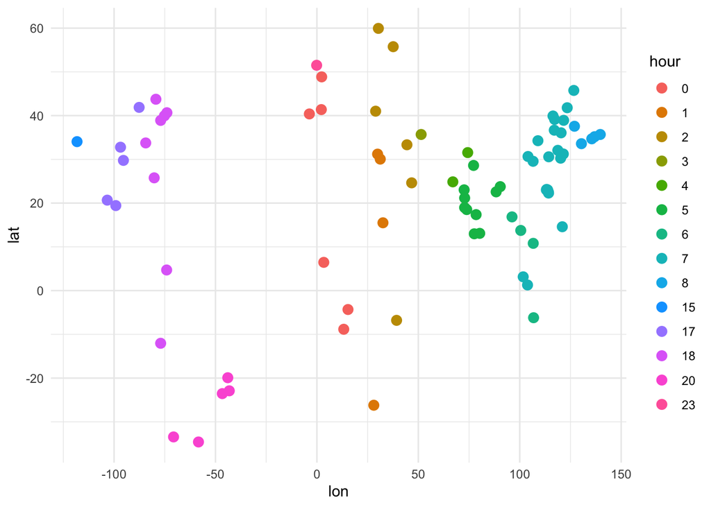

```r
# Question 02
output %>%
  mutate(hour = factor(hour)) %>%
  ggplot(aes(lon, lat)) +
    geom_point(aes(color = hour), size = 3)
```

## Aesops Fables

Similar to the XKCD API, we can grab the text of Aesops fables from read.gov through the following URL for any id between 2 and 147.

```r
i <- 10
url_str <- modify_url(sprintf("https://www.read.gov/aesop/%03d.html", i))
```

This is HTML format. We can parse it just as we did the CNN Lite data to get the text in paragraph codes (p) and the title in the header tag h1.

In the following code, create a docs that contains the title and text of each fable. Please ask for help; you’ll probably need it!

```r
# Question 03
docs <- vector("list", length = 146)

for (i in seq(1, 146))
{
  url_str <- modify_url(sprintf("https://www.read.gov/aesop/%03d.html", i + 1))
  res <- dsst_cache_get(url_str, cache_dir = "cache")
  obj <- content(res, type = "text/html", encoding = "UTF-8")

  docs[[i]] <- tibble(
    doc_id = xml_text(xml_find_all(obj, "..//h1")),
    train_id = "train",
    text = paste0(xml_text(xml_find_all(obj, "..//p")), collapse = " ")
  )
}

docs <- bind_rows(docs)
docs
```

```
## # A tibble: 146 × 3
##    doc_id                             train_id text
##    <chr>                              <chr>    <chr>
##  1 The Frogs & the Ox                 train    "An Ox came down to a reedy …
##  2 Belling the Cat                    train    "The Mice once called a meet…
##  3 The Town Mouse & the Country Mouse train    "A Town Mouse once visited a…
##  4 The Fox & the Grapes               train    "A Fox one day spied a beaut…
##  5 The Wolf & the Crane               train    "A Wolf had been feasting to…
##  6 The Lion & the Mouse               train    "A Lion lay asleep in the fo…
##  7 The Gnat & the Bull                train    "A Gnat flew over the meadow…
##  8 The Plane Tree                     train    "Two Travellers, walking in …
##  9 The Owl & the Grasshopper          train    "The Owl always takes her sl…
## 10 The Oak & the Reeds                train    "A Giant Oak stood near a br…
## # … with 136 more rows
```

Two of the fable names are repeated. I suggest removing them:

```r
docs <- docs %>%
  filter(!duplicated(doc_id))
```

Now, create an annotation table of the fables:

```r
# Question 04
library(cleanNLP)
cnlp_init_udpipe("english")

docs <- filter(docs, stringi::stri_length(text) > 0)
anno <- cnlp_annotate(docs)$token
```

[output not shown]

Now, use the data to produce a UMAP plot of the nouns and verbs along with the titles of the stories. Make the font size small (2?) to allow the plot to be more readable.

```
## as(<dgCMatrix>, "dgTMatrix") is deprecated since Matrix 1.5-0; do as(., "TsparseMatrix") instead
```

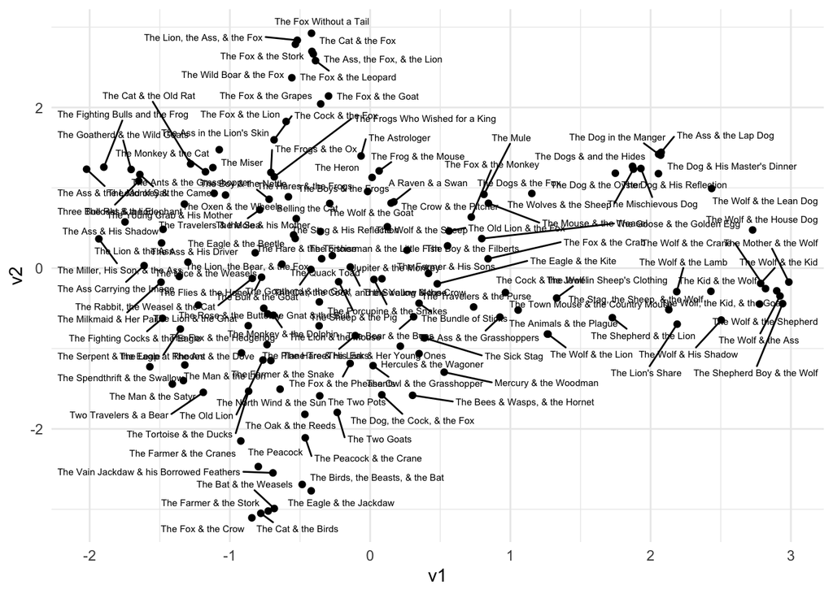

```r
# Question 05
anno %>%
  filter(upos %in% c("NOUN", "VERB")) %>%
  dsst_umap() %>%
  ggplot(aes(v1, v2)) +
    geom_point() +
    geom_text_repel(aes(label = doc_id), size = 2)
```

```r
# Question 06
anno %>%
  filter(upos %in% c("NOUN", "VERB")) %>%
  dsst_metrics(docs, label_var = "doc_id") %>%
  filter(count > expected) %>%
  group_by(label) %>%
  slice_head(n = 6L) %>%
  summarize(terms = paste0(token, collapse = "; ")) %>%
  mutate(out = sprintf("%30 s => %s", stri_sub(label, 1, 30), terms)) %>%
  getElement("out") %>%
  cat(sep = "\n")
```

```
##               A Raven & a Swan => feather; live; diive; drown; remain; wash
##                Belling the Cat => plan; mouse; cat; enemy; know; discuss
##         Hercules & the Wagoner => wagon; wheel; urge; effort; farmer; move
##           Jupiter & the Monkey => baby; prize; animal; pop; provide; imagine
##          Mercury & the Woodman => one; pool; div; appear; silver; fortune
##       The Animals & the Plague => sacrifice; belong; crime; majesty; admit; beasts
##             The Ant & the Dove => straw; stone; brook; pity; float; miss
##     The Ants & the Grasshopper => store; summer; music; Grasshopper; begge; shoulders
##           The Ass & His Driver => mountain; lead; side; pull; path; silly
##           The Ass & His Shadow => traveler; ass; heat; shade; cast; shadow
##     The Ass & the Grasshoppers => Grasshopper; s; song; drink; admiration; heart
##          The Ass & the Lap Dog => master; table; stable; ass; lick; face
##     The Ass & the Load of Salt => load; seashore; cross; river; ass; foot
##     The Ass Carrying the Image => ass; honor; head; adorn; midst; priest
##     The Ass in the Lion's Skin => bray; ass; animal; frightene; hunter; keep
##   The Ass, the Fox, & the Lion => ass; hurt; promise; lead; bit; fox
##                 The Astrologer => star; hole; mud; earth; front; spend
##          The Bat & the Weasels => Weasel; bird; mouse; go; eat; enemy
##            The Bear & the Bees => swarm; log; diive; happene; clover; destroy
## The Bees & Wasps, & the Hornet => honey; case; judge; belong; build; witness
## The Birds, the Beasts, & the B => battle; cause; family; race; bird; tooth
##         The Boy & the Filberts => hand; get; permission; give; boy; pitcher
##           The Boy & the Nettle => mother; grasp; kiss; sting; hurt; blow
##           The Boys & the Frogs => pond; play; stone; trembl; water; mean
##            The Bull & the Goat => cave; insult; stormy; leave; enter; prowl
##           The Bundle of Sticks => stick; break; son; example; untie; mind
##            The Cat & the Birds => bird; knock; medicine; doctor; pee; neighborhood
##              The Cat & the Fox => hound; trick; fox; cat; one; dodge
##          The Cat & the Old Rat => cat; distance; hang; keep; celebrate; heap
## The Cat, the Cock, and the You => monster; look; creature; mother; mouse; acquaintance
##             The Cock & the Fox => news; wait; cock; hear; wing; bury
##           The Cock & the Jewel => lose; owner; choose; scratch; deal; find
##         The Crow & the Pitcher => pitcher; pebble; water; Crow; drink; thirst
##  The Dog & His Master's Dinner => basket; neighborhood; dinner; dog; duty; tempt
##       The Dog & His Reflection => bone; dog; think; mirror; scramble; whom
##           The Dog & the Oyster => egg; groaning; he; shell; wander; pain
##          The Dog in the Manger => dog; fill; asleep; awaken; behavior; snarl
##   The Dog, the Cock, & the Fox => cock; awaken; roost; tree; farmyard; wood
##       The Dogs & and the Hides => hide; river; water; dog; drinking; remain
##             The Dogs & the Fox => tooth; story; tear; skin; chance; laugh
```

[output cut: 89 more lines]

```
##           The Wolf & the Crane => bone; reward; throat; wolf; Crane; pull
##            The Wolf & the Goat => cliff; grass; steep; appetite; listen; edge
##       The Wolf & the House Dog => wolf; dog; difference; mark; reply; skin
##             The Wolf & the Kid => kid; tune; flock; grass; song; start
##            The Wolf & the Lamb => stream; lamb; brother; year; morning; highness
##        The Wolf & the Lean Dog => dog; wolf; porter; eat; promise; master
##            The Wolf & the Lion => property; change; lair; make; right; steal
##           The Wolf & the Sheep => drink; food; sheep; hunger; suppose; thirst
##        The Wolf & the Shepherd => flock; shepherd; wolf; care; sheep; errand
##   The Wolf in Sheep's Clothing => skin; even; mutton; enter; stroll; cast
##  The Wolf, the Kid, & the Goat => kid; door; wolf; race; paw; show
##         The Wolves & the Sheep => dog; sheep; even; lurk; persuade; Wolves
##    The Young Crab & His Mother => walk; crab; son; want; turn; trip
##        Three Bullocks & a lion => field; attack; watch; accustom; feeding; hope
##         Two Travelers & a Bear => man; climb; company; brush; savage; touch
```